# Introduction and overview

This is the third and final chapter of the Godot simulation game course.

This series is a follow-up on the previous chapter, where we implemented a grid-based inventory system.

We’ll be proceeding from there and cover the following:

- Displaying tooltips over machines to see item descriptions and work progress.
- A central place to configure crafting recipes.
- A GUI to manually craft items from the inventory’s content.
- Machine-specific GUIs and inventories.
- Making machines do automated work, like crafting metal ore into metal ingots using fuel.

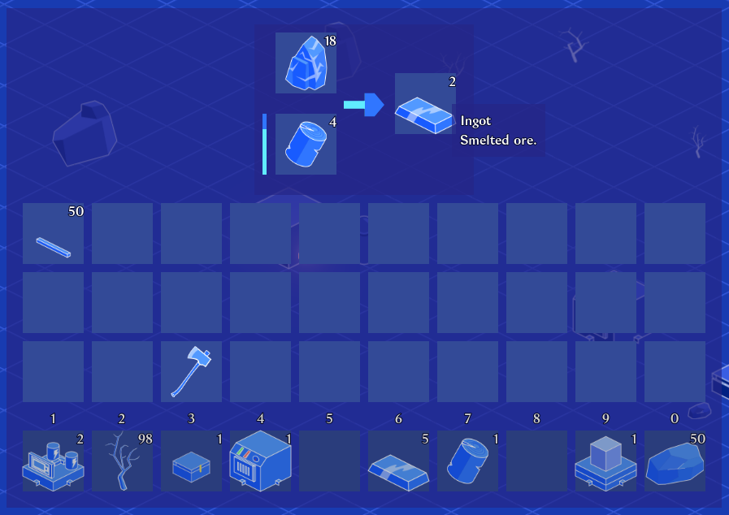

As always, we welcome feedback and questions. You can leave them directly under any lesson on the platform.

## Downloading the project

You can find the fully completed project on the [Godot 2D Builder](https://github.com/gdquest/godot-2d-builder) repository.

You can also find the starter project for the chapter inside the course’s downloads, `start-project-3/`. It contains the result of the previous chapter if you need to skip ahead.

## The chapter’s code structure

To implement the features, we’ll use the following structure as a guide.

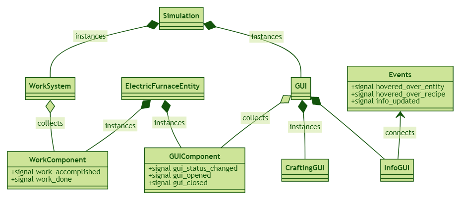

The `GUI` node will be responsible for the new crafting GUI and the tooltip that appears when hovering over objects.

It still acts as a gateway for the inventory and input to minimize coupling.

We’ll keep crafting simple.

The crafting GUI will analyze the contents of the player’s inventory and provides a list of objects they can craft. If the user clicks on one of those, the player crafts the item, puts it into their inventory, and consumes the source materials.

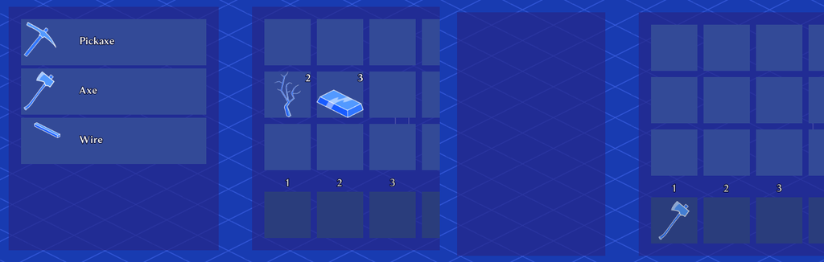

We’ll introduce new components and systems for entities.

The `GUIComponent` will act as a container for the machines’ GUI to provide machines with inventory and any crafting interface.

We’ll treat it like the quick-bar. It’ll jump in and out of the inventory window to display itself to the player.

The `WorkComponent` and `WorkSystem` function like the `PowerSystem` with its `PowerSource` and `PowerReceiver` components.

They do general work that the entity can use to function, like crafting items automatically following recipes. For example, turning ore into ingots.

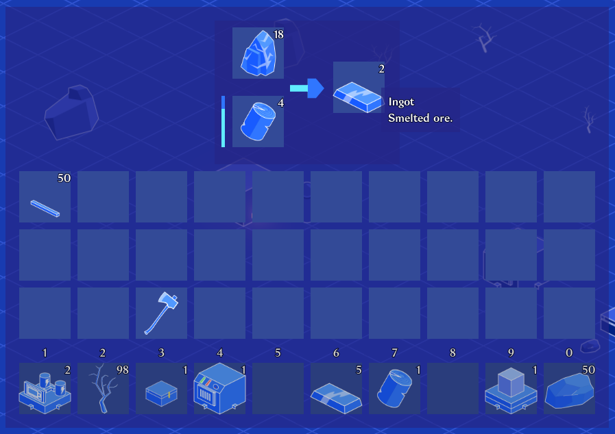

In the next lesson, we’ll add the information label and provide a function inside of entities to get information when the user mouses over anything.

Let’s get cracking.